# Wine Quality "Warm up" Challenge

### Physicochemical factors that predict good quality wine

#### Group 11: Yazid Mouline & Guillaume Requena

```python
#imports
import matplotlib.pyplot as plt
import numpy as np
import pandas as pd
import seaborn as sns
from sklearn.model_selection import train_test_split
from sklearn.preprocessing import StandardScaler
from sklearn.linear_model import LogisticRegression
from sklearn.metrics import log_loss
from sklearn.neighbors import KNeighborsClassifier
from sklearn.model_selection import GridSearchCV
from sklearn.ensemble import RandomForestClassifier
from sklearn.model_selection import StratifiedKFold

import math

!pip install -U -q PyDrive
from pydrive.auth import GoogleAuth
from pydrive.drive import GoogleDrive
from google.colab import auth
from oauth2client.client import GoogleCredentials
from sklearn.metrics import roc_curve, auc
```

### 1. Data preparation

#### 1.1. Data exploration

```python
#Loading the datasets using file from Google Drive



# Authenticate and create the PyDrive client.
auth.authenticate_user()
gauth = GoogleAuth()
gauth.credentials = GoogleCredentials.get_application_default()
drive = GoogleDrive(gauth)

#Loading whitewine
link = 'https://drive.google.com/open?id=12CFLiUdaMMlJshxVt_BMczxDsP5dlT5f' # The shareable link
fluff, id = link.split('=')
downloaded = drive.CreateFile({'id':id})
downloaded.GetContentFile('winequality-white.csv')
whitewine = pd.read_csv('winequality-white.csv', sep=';')

#Loading whitewine
link = 'https://drive.google.com/open?id=1Mgbu3xWvPN85GAnwRSG2rtrcgJBijCfH' # The shareable link
fluff, id = link.split('=')
downloaded = drive.CreateFile({'id':id})
downloaded.GetContentFile('winequality-red.csv')
redwine = pd.read_csv('winequality-red.csv', sep=';')
```

```python
#checking the datasets distribution
redwine.head()
```

|  | fixed acidity | volatile acidity | citric acid | residual sugar | chlorides | free sulfur dioxide | total sulfur dioxide | density | pH | sulphates | alcohol | quality |
| --- | --- | --- | --- | --- | --- | --- | --- | --- | --- | --- | --- | --- |
| 0 | 7.4 | 0.70 | 0.00 | 1.9 | 0.076 | 11.0 | 34.0 | 0.9978 | 3.51 | 0.56 | 9.4 | 5 |
| 1 | 7.8 | 0.88 | 0.00 | 2.6 | 0.098 | 25.0 | 67.0 | 0.9968 | 3.20 | 0.68 | 9.8 | 5 |
| 2 | 7.8 | 0.76 | 0.04 | 2.3 | 0.092 | 15.0 | 54.0 | 0.9970 | 3.26 | 0.65 | 9.8 | 5 |
| 3 | 11.2 | 0.28 | 0.56 | 1.9 | 0.075 | 17.0 | 60.0 | 0.9980 | 3.16 | 0.58 | 9.8 | 6 |
| 4 | 7.4 | 0.70 | 0.00 | 1.9 | 0.076 | 11.0 | 34.0 | 0.9978 | 3.51 | 0.56 | 9.4 | 5 |

```python
whitewine.head()
```

|  | fixed acidity | volatile acidity | citric acid | residual sugar | chlorides | free sulfur dioxide | total sulfur dioxide | density | pH | sulphates | alcohol | quality |
| --- | --- | --- | --- | --- | --- | --- | --- | --- | --- | --- | --- | --- |
| 0 | 7.0 | 0.27 | 0.36 | 20.7 | 0.045 | 45.0 | 170.0 | 1.0010 | 3.00 | 0.45 | 8.8 | 6 |
| 1 | 6.3 | 0.30 | 0.34 | 1.6 | 0.049 | 14.0 | 132.0 | 0.9940 | 3.30 | 0.49 | 9.5 | 6 |
| 2 | 8.1 | 0.28 | 0.40 | 6.9 | 0.050 | 30.0 | 97.0 | 0.9951 | 3.26 | 0.44 | 10.1 | 6 |
| 3 | 7.2 | 0.23 | 0.32 | 8.5 | 0.058 | 47.0 | 186.0 | 0.9956 | 3.19 | 0.40 | 9.9 | 6 |
| 4 | 7.2 | 0.23 | 0.32 | 8.5 | 0.058 | 47.0 | 186.0 | 0.9956 | 3.19 | 0.40 | 9.9 | 6 |

The shape of the redwine dataframe is (1599, 12) and the shape of the whitewine dataframe is (4898, 12), meaning that for both, we have 12 columns, corresponding to the 11 different features (we can read them above) and the last column for the label (quality). There are respectively 1599 and 4898 different entries.

Also, there is no null value.

#### 1.2. Data cleaning

```python
# dropping duplicates by row

redwine = redwine.drop_duplicates()
whitewine = whitewine.drop_duplicates()
```

There are a few less rows for each dataset (1359 and 3961).

#### 1.3. Data visualisation

For the next cells, we'll plot the distribution of each column according to each 'quality'. In other words, we will try to check how a given feature influences the wine quality. Also, we'll do it independently for both datasets to check if there is any difference in trends.

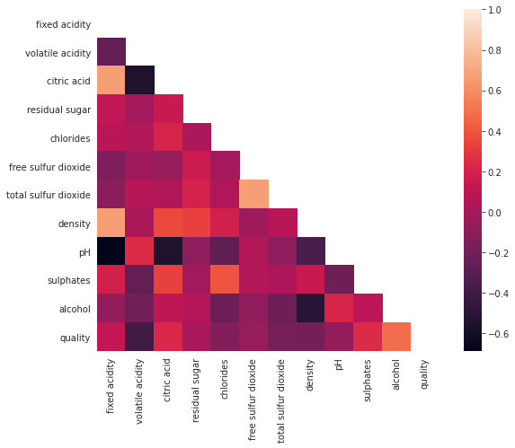

```python
fig = plt.figure(1, figsize=(10,7))
correlation_matrix = redwine.corr()
mask = np.zeros_like(correlation_matrix)
mask[np.triu_indices_from(mask)] = True
with sns.axes_style("white"):
    ax = sns.heatmap(correlation_matrix, mask=mask, square=True)
```

We realized that the most correlated features with quality is alcohol. So we decided to add a polynomial feature : alcohol*2.

```python
redwine['alcohol^2']=redwine['alcohol']**2
```

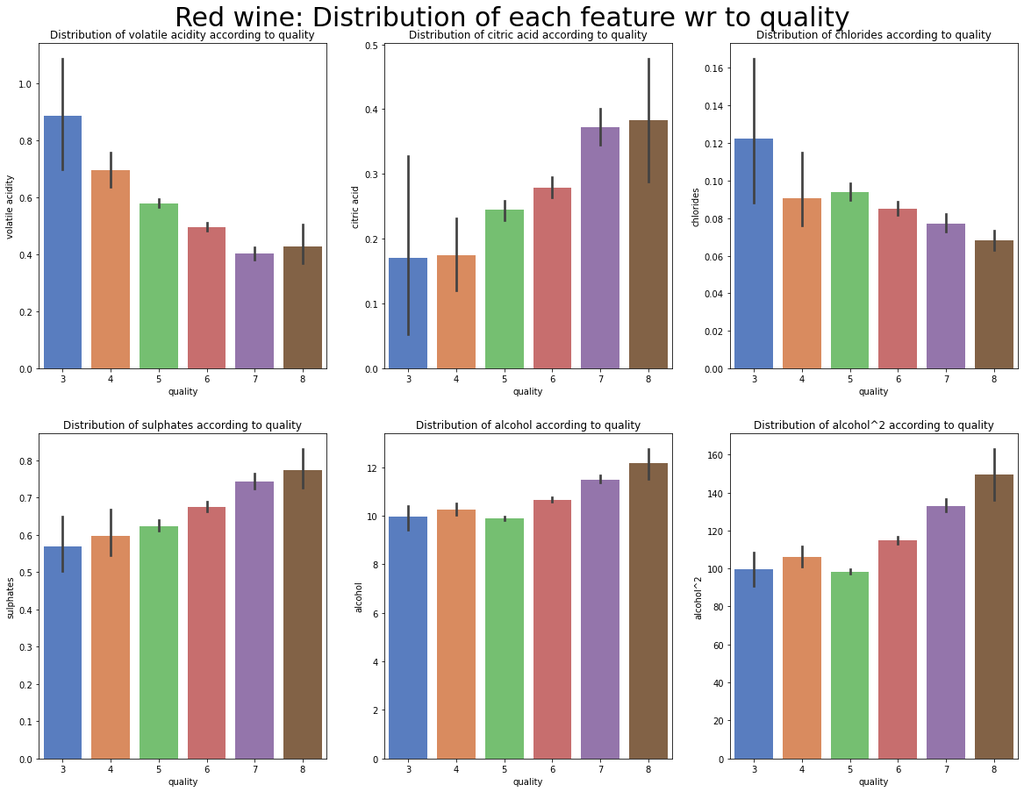

```python
fig = plt.figure(figsize = (20,15))
red_features = ['volatile acidity', 'citric acid', 'chlorides', 'sulphates', 'alcohol', 'alcohol^2']
for i,red_feature in enumerate(red_features):
    plt.subplot(2,3,i+1)
    sns.barplot(x = 'quality', y = red_feature, data = redwine, palette='muted')
    plt.title('Distribution of '+red_feature+' according to quality')
fig.suptitle('Red wine: Distribution of each feature wr to quality', y=0.92, fontsize=30)
plt.show()
```

**Comments**

The histograms above allow us to extract various trends and information about each feature for the redwine dataset.

First there are some features that seem to be more or less similar or independent of quality. These features will not allow us to give any specification to classify the wine's quality. Fixed acidity, residual sugar, density, or pH. Also, free and total sulfur dioxide are low for good and bad wines and high for middle quality wines.

On the other hand, there are some features that seem to have a linear influence on the quality and will allow us to classify the wines by quality easily.

- Volatile acidity goes down with quality
- Citric acid goes up with quality
- Chlorides goes down with quality
- Sulphates goes up with quality
- Alcohol goes up with quality

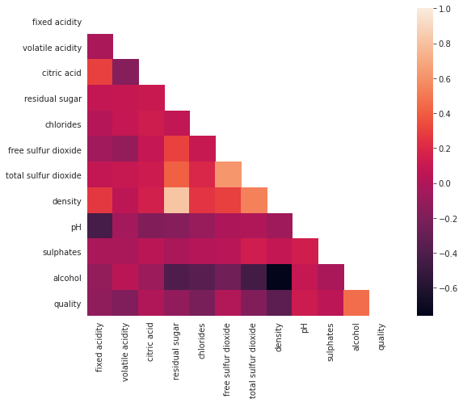

```python
fig = plt.figure(1, figsize=(10,7))
correlation_matrix = whitewine.corr()
mask = np.zeros_like(correlation_matrix)
mask[np.triu_indices_from(mask)] = True
with sns.axes_style("white"):
    ax = sns.heatmap(correlation_matrix, mask=mask, square=True)
```

We realized that the most correlated features with quality is alcohol. So we decided to add a polynomial feature : alcohol*2.

```python
whitewine['alcohol^2']=whitewine['alcohol']**2
```

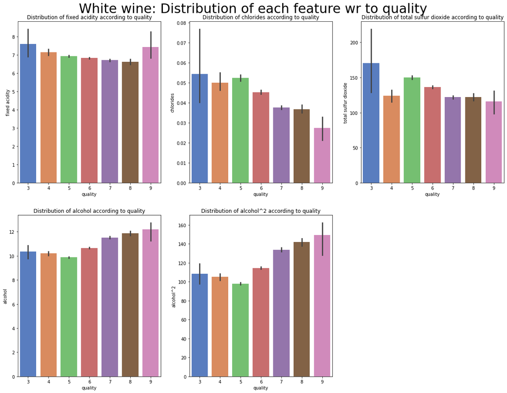

```python
fig = plt.figure(figsize = (20,15))
plt.title('White wine: Distribution of each feature wr to quality')
white_features = ['fixed acidity', 'chlorides', 'total sulfur dioxide', 'alcohol', 'alcohol^2']
for i,white_feature in enumerate(white_features):
    plt.subplot(2,3,i+1)
    sns.barplot(x = 'quality', y = white_feature, data = whitewine, palette='muted')
    plt.title('Distribution of '+white_feature+' according to quality')
fig.suptitle('White wine: Distribution of each feature wr to quality', y=0.92, fontsize=30)
plt.show()
```

**Comments**

The histograms above allow us to extract various trends and information about each feature for the whitewine dataset.

The trends are very much similar compared to the other dataset except for some slight differences. Volatile and citric acidity do no have the same smooth trends.

Here :

- Fixed acidity goes down with quality and raise for the highest quality (parabol)
- Chlorides goes down with quality
- Total sulfur dioxide goes down with quality
- Alcohol goes up with quality
- Alcohol^2 goes up with quality

**Comments**

Some features are more or less correlated with quality, but we cannot pretend to remove arbitrarily some features according to the fact that we will lose global information and it can mistrain the data. Thus we decide to keep all features.

Trying to apply a RFECV method (Recursive Feature Elimination) and also a PCA (Principal Component Analysis) for feature reduction we noticed that these methods are costly and do not improve our dataset much. Indeed, the datasets are taken from UCI Machine Learning Datasets that offer very clean datasets.

We choose then to keep all the features given.

#### 1.4. Data preprocessing

Following the tip, we will divide our dataset into two different qualities, good and not good, using the threshold quality >= 7.

```python
redwine['good'] = redwine['quality'] > 6
redwine['good'] = redwine['good'].astype(int)

whitewine['good'] = whitewine['quality'] > 6
whitewine['good'] = whitewine['good'].astype(int)
```

Below, we check the distribution of the quality, and of the binary label created good.

Also, we made the choice to keep both databases separated, it seems more relevant: to determine the quality of a wine according to its chemical characteristics would require the knowledge of its type.

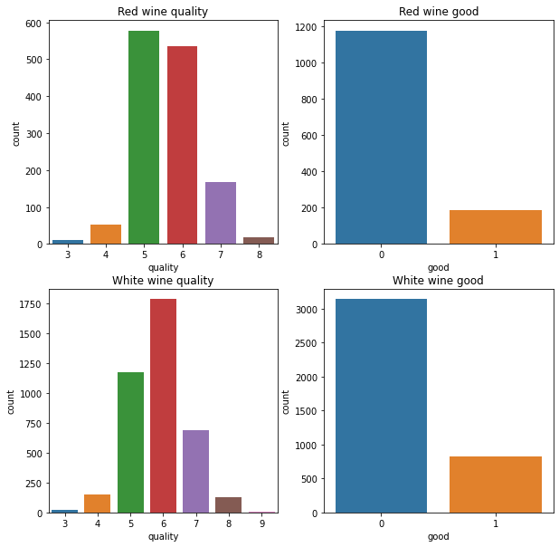

```python
fig = plt.figure(figsize=(10,10))

plt.subplot(2,2,1)
sns.countplot(redwine['quality'])
plt.title("Red wine quality")

plt.subplot(2,2,2)
sns.countplot(redwine['good'])
plt.title("Red wine good")

plt.subplot(2,2,3)
sns.countplot(whitewine['quality'])
plt.title("White wine quality")

plt.subplot(2,2,4)
sns.countplot(whitewine['good'])
plt.title("White wine good")

plt.show()
```

```python
nb_bad_red = redwine[redwine['good']==0]['good'].count()
nb_good_red = redwine[redwine['good']==1]['good'].count()
total_red = nb_bad_red + nb_good_red

nb_bad_white = whitewine[whitewine['good']==0]['good'].count()
nb_good_white = whitewine[whitewine['good']==1]['good'].count()
total_white = nb_bad_white + nb_good_white

print('Red Wine \nThere is {nb}% of bad red wine in the dataset.'.format(nb = 100*nb_bad_red/total_red))
print('There is {nb}% of good red wine in the dataset.\n'.format(nb = 100*nb_good_red/total_red))

print('White Wine \nThere is {nb}% of bad white wine in the dataset.'.format(nb = 100*nb_bad_white/total_white))
print('There is {nb}% of good white wine in the dataset.\n'.format(nb = 100*nb_good_white/total_white))

print('The dataset is unbalanced, so we will need to be careful about sensitivity\n'\
          +'and specifity later on while the accuracy could be a wrong metric.')
```

```
Red Wine
There is 86.46063281824871% of bad red wine in the dataset.
There is 13.539367181751288% of good red wine in the dataset.

White Wine
There is 79.17192628124211% of bad white wine in the dataset.
There is 20.82807371875789% of good white wine in the dataset.

The dataset is unbalanced, so we will need to be careful about sensitivity
and specifity later on while the accuracy could be a wrong metric.
```

```python
#We drop the column quality

redwine = redwine.drop('quality', axis=1)

whitewine = whitewine.drop('quality', axis=1)
```

```python
#We separate the dataset into X and y and then into train and test sets

Xred = redwine.drop('good', axis=1)
yred = redwine['good']

Xred_train, Xred_test, yred_train, yred_test = train_test_split(Xred, yred, test_size = 0.2, random_state = 42)

Xwhite = whitewine.drop('good', axis=1)
ywhite = whitewine['good']

Xwhite_train, Xwhite_test, ywhite_train, ywhite_test = train_test_split(Xwhite, ywhite, test_size = 0.2, random_state = 42)
```

```python
#We normalize our features
sc = StandardScaler()

Xred_train = sc.fit_transform(Xred_train)
Xred_test = sc.fit_transform(Xred_test)

Xwhite_train = sc.fit_transform(Xwhite_train)
Xwhite_test = sc.fit_transform(Xwhite_test)
```

### 2. Model Selection

#### 2.1. Logistic Regression

```python
clf_red = LogisticRegression(random_state=0)
clf_red.fit(Xred_train, yred_train)

yred_train_pred_logistic = clf_red.predict(Xred_train)
accred__train_logistic = clf_red.score(Xred_train,yred_train)
loglossred_train_logistic = log_loss(yred_train, yred_train_pred_logistic)
fpr_red_train_logistic, tpr_red_train_logistic, _ = roc_curve(yred_train, yred_train_pred_logistic)
roc_auc_red_train_logistic = auc(fpr_red_train_logistic, tpr_red_train_logistic)

yred_test_pred_logistic = clf_red.predict(Xred_test)
accred__test_logistic = clf_red.score(Xred_test, yred_test)
loglossred_test_logistic = log_loss(yred_test, yred_test_pred_logistic)
fpr_red_test_logistic, tpr_red_test_logistic, _ = roc_curve(yred_test, yred_test_pred_logistic)
roc_auc_red_test_logistic = auc(fpr_red_test_logistic, tpr_red_test_logistic)

print("LOGISTIC REGRESSION RESULTS FOR THE REDWINE DATASET\n")
print("The training accuracy is: {}".format(accred__train_logistic))
print("The testing accuracy is: {}\n".format(accred__test_logistic))
print("The training logloss is {}".format(loglossred_train_logistic))
print("The testing logloss is {}\n".format(loglossred_test_logistic))
print("The training AUC is {}".format(roc_auc_red_train_logistic))
print("The testing AUC is {}\n".format(roc_auc_red_test_logistic))

clf_white = LogisticRegression(random_state=0)
clf_white.fit(Xwhite_train, ywhite_train)

ywhite_train_pred_logistic = clf_white.predict(Xwhite_train)
accwhite__train_logistic = clf_white.score(Xwhite_train, ywhite_train)
loglosswhite_train_logistic = log_loss(ywhite_train, ywhite_train_pred_logistic)
fpr_white_train_logistic, tpr_white_train_logistic, _ = roc_curve(ywhite_train, ywhite_train_pred_logistic)
roc_auc_white_train_logistic = auc(fpr_white_train_logistic, tpr_white_train_logistic)

ywhite_test_pred_logistic = clf_white.predict(Xwhite_test)
accwhite__test_logistic = clf_white.score(Xwhite_test, ywhite_test)
loglosswhite_test_logistic = log_loss(ywhite_test, ywhite_test_pred_logistic)
fpr_white_test_logistic, tpr_white_test_logistic, _ = roc_curve(ywhite_test, ywhite_test_pred_logistic)
roc_auc_white_test_logistic = auc(fpr_white_test_logistic, tpr_white_test_logistic)

print(" ")
print("LOGISTIC REGRESSION RESULTS FOR THE WHITEWINE DATASET\n")
print("The training accuracy is: {}".format(accwhite__train_logistic))
print("The testing accuracy is: {}\n".format(accwhite__test_logistic))
print("The training logloss is {}".format(loglosswhite_train_logistic))
print("The testing logloss is {}\n".format(loglosswhite_test_logistic))
print("The training AUC is {}".format(roc_auc_white_train_logistic))
print("The testing AUC is {}".format(roc_auc_white_test_logistic))
```

```
LOGISTIC REGRESSION RESULTS FOR THE REDWINE DATASET

The training accuracy is: 0.8767249310027599
The testing accuracy is: 0.8933823529411765

The training logloss is 4.257794317969852
The testing logloss is 3.6824665890876895

The training AUC is 0.645723941657773
The testing AUC is 0.6743697478991597


LOGISTIC REGRESSION RESULTS FOR THE WHITEWINE DATASET

The training accuracy is: 0.8159722222222222
The testing accuracy is: 0.8095838587641866

The training logloss is 6.3561296028640015
The testing logloss is 6.57677279035218

The training AUC is 0.6314309280870044
The testing AUC is 0.6341100323624596
```

**Comments**

We chose to only separate the datasets into a training and testing set. The results above can then be somehow improved. Because the Random Forest Classifier seemed to be the algorithm working best, we'll use a cross validation technique there to improve our results.

#### 2.2. K Nearest Neighbors

```python
scores_list_red = []
scores_list_white = []
k_range = range(1,40)
for k in k_range:
   knn = KNeighborsClassifier(n_neighbors=k)
   knn.fit(Xred_train,yred_train)
   yred_pred = knn.predict(Xred_test)
   scores_list_red.append(log_loss(yred_test, yred_pred))
for k in k_range:
   knn = KNeighborsClassifier(n_neighbors=k)
   knn.fit(Xwhite_train,ywhite_train)
   ywhite_pred = knn.predict(Xwhite_test)
   scores_list_white.append(log_loss(ywhite_test, ywhite_pred))
```

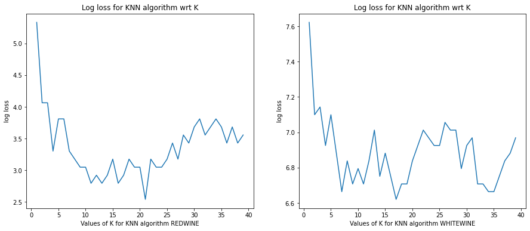

```python
fig = plt.figure(figsize=(15,6))

plt.subplot(1,2,1)
plt.plot(k_range, scores_list_red)
plt.xlabel('Values of K for KNN algorithm REDWINE')
plt.ylabel('log loss')
plt.title('Log loss for KNN algorithm wrt K')

plt.subplot(1,2,2)
plt.plot(k_range, scores_list_white)
plt.xlabel('Values of K for KNN algorithm WHITEWINE')
plt.ylabel('log loss')
plt.title('Log loss for KNN algorithm wrt K')
```

```python
red_K = scores_list_red.index(min(scores_list_red)) + 1
white_K = scores_list_white.index(min(scores_list_white)) + 1

print("The value of K for which KNN is optimal for redwine is " + str(red_K))
print("The value of K for which KNN is optimal for whitewine is " + str(white_K))
```

```
The value of K for which KNN is optimal for redwine is 21
The value of K for which KNN is optimal for whitewine is 17
```

```python
knn_red = KNeighborsClassifier(n_neighbors=red_K)
knn_red.fit(Xred_train, yred_train)

yred_train_pred_knn = knn_red.predict(Xred_train)
accred__train_knn = knn_red.score(Xred_train,yred_train)
loglossred_train_knn = log_loss(yred_train, yred_train_pred_knn)
fpr_red_train_knn, tpr_red_train_knn, _ = roc_curve(yred_train, yred_train_pred_knn)
roc_auc_red_train_knn = auc(fpr_red_train_knn, tpr_red_train_knn)

yred_test_pred_knn = clf_red.predict(Xred_test)
accred__test_knn = clf_red.score(Xred_test, yred_test)
loglossred_test_knn = log_loss(yred_test, yred_test_pred_knn)
fpr_red_test_knn, tpr_red_test_knn, _ = roc_curve(yred_test, yred_test_pred_knn)
roc_auc_red_test_knn = auc(fpr_red_test_knn, tpr_red_test_knn)

print("KNN RESULTS FOR THE REDWINE DATASET\n")
print("The training accuracy is: {}".format(accred__train_knn))
print("The testing accuracy is: {}\n".format(accred__test_knn))
print("The training logloss is {}".format(loglossred_train_knn))
print("The testing logloss is {}\n".format(loglossred_test_knn))
print("The training AUC is {}".format(roc_auc_red_train_knn))
print("The testing AUC is {}\n".format(roc_auc_red_test_knn))

knn_white = KNeighborsClassifier(n_neighbors=white_K)
knn_white.fit(Xwhite_train, ywhite_train)

ywhite_train_pred_knn = knn_white.predict(Xwhite_train)
accwhite__train_knn = knn_white.score(Xwhite_train, ywhite_train)
loglosswhite_train_knn = log_loss(ywhite_train, ywhite_train_pred_knn)
fpr_white_train_knn, tpr_white_train_knn, _ = roc_curve(ywhite_train, ywhite_train_pred_knn)
roc_auc_white_train_knn = auc(fpr_white_train_knn, tpr_white_train_knn)

ywhite_test_pred_knn = knn_white.predict(Xwhite_test)
accwhite__test_knn = knn_white.score(Xwhite_test, ywhite_test)
loglosswhite_test_knn = log_loss(ywhite_test, ywhite_test_pred_knn)
fpr_white_test_knn, tpr_white_test_knn, _ = roc_curve(ywhite_test, ywhite_test_pred_knn)
roc_auc_white_test_knn = auc(fpr_white_test_knn, tpr_white_test_knn)

print(" ")
print("KNN RESULTS FOR THE WHITEWINE DATASET\n")
print("The training accuracy is: {}".format(accwhite__train_knn))
print("The testing accuracy is: {}\n".format(accwhite__test_knn))
print("The training logloss is {}".format(loglosswhite_train_knn))
print("The testing logloss is {}\n".format(loglosswhite_test_knn))
print("The training AUC is {}".format(roc_auc_white_train_knn))
print("The testing AUC is {}".format(roc_auc_white_test_knn))
```

```
KNN RESULTS FOR THE REDWINE DATASET

The training accuracy is: 0.8739650413983441
The testing accuracy is: 0.8933823529411765

The training logloss is 4.353116056690984
The testing logloss is 3.6824665890876895

The training AUC is 0.6301245108502314
The testing AUC is 0.6743697478991597


KNN RESULTS FOR THE WHITEWINE DATASET

The training accuracy is: 0.8396464646464646
The testing accuracy is: 0.8083228247162674

The training logloss is 5.538444937092431
The testing logloss is 6.62032635504005

The training AUC is 0.6771393657970306
The testing AUC is 0.6292048081368469
```

#### 2.3. Random Forest Classifier

We use the Grid Search CV technique to optimize our parameters. Since it is the warm up challenge, we haven't tuned the parameters much since the exectutions are quite long.

```python
rfcred = RandomForestClassifier(random_state=42)
rfcwhite = RandomForestClassifier(random_state=42)


# Number of trees in random forest
n_estimators = [180,190,200,210,220]
# Maximum number of levels in tree
max_depth = [12,14,16]
# Minimum number of samples required to split a node
min_samples_split = [2]
# Minimum number of samples required at each leaf node
min_samples_leaf = [2]
# Create the random grid
random_grid = {'n_estimators': n_estimators,
               'max_depth': max_depth,
               'min_samples_split': min_samples_split,
               'min_samples_leaf': min_samples_leaf}
```

```python
CV_rfcred = GridSearchCV(estimator=rfcred, param_grid=random_grid, cv=5, scoring='neg_log_loss')
CV_rfcwhite = GridSearchCV(estimator=rfcwhite, param_grid=random_grid, cv=5, scoring='neg_log_loss')
```

```python
CV_rfcred.fit(Xred_train, yred_train)
```

```
GridSearchCV(cv=5, error_score=nan,
             estimator=RandomForestClassifier(bootstrap=True, ccp_alpha=0.0,
                                              class_weight=None,
                                              criterion='gini', max_depth=None,
                                              max_features='auto',
                                              max_leaf_nodes=None,
                                              max_samples=None,
                                              min_impurity_decrease=0.0,
                                              min_impurity_split=None,
                                              min_samples_leaf=1,
                                              min_samples_split=2,
                                              min_weight_fraction_leaf=0.0,
                                              n_estimators=100, n_jobs=None,
                                              oob_score=False, random_state=42,
                                              verbose=0, warm_start=False),
             iid='deprecated', n_jobs=None,
             param_grid={'max_depth': [12, 14, 16], 'min_samples_leaf': [2],
                         'min_samples_split': [2],
                         'n_estimators': [180, 190, 200, 210, 220]},
             pre_dispatch='2*n_jobs', refit=True, return_train_score=False,
             scoring='neg_log_loss', verbose=0)
```

```python
CV_rfcwhite.fit(Xwhite_train, ywhite_train)
```

```
GridSearchCV(cv=5, error_score=nan,
             estimator=RandomForestClassifier(bootstrap=True, ccp_alpha=0.0,
                                              class_weight=None,
                                              criterion='gini', max_depth=None,
                                              max_features='auto',
                                              max_leaf_nodes=None,
                                              max_samples=None,
                                              min_impurity_decrease=0.0,
                                              min_impurity_split=None,
                                              min_samples_leaf=1,
                                              min_samples_split=2,
                                              min_weight_fraction_leaf=0.0,
                                              n_estimators=100, n_jobs=None,
                                              oob_score=False, random_state=42,
                                              verbose=0, warm_start=False),
             iid='deprecated', n_jobs=None,
             param_grid={'max_depth': [12, 14, 16], 'min_samples_leaf': [2],
                         'min_samples_split': [2],
                         'n_estimators': [180, 190, 200, 210, 220]},
             pre_dispatch='2*n_jobs', refit=True, return_train_score=False,
             scoring='neg_log_loss', verbose=0)
```

```python
CV_rfcwhite.best_params_
```

```
{'max_depth': 12,
 'min_samples_leaf': 2,
 'min_samples_split': 2,
 'n_estimators': 210}
```

```python
rfcred_result = CV_rfcred.best_estimator_
rfcred_result.fit(Xred_train, yred_train)
```

```
RandomForestClassifier(bootstrap=True, ccp_alpha=0.0, class_weight=None,
                       criterion='gini', max_depth=16, max_features='auto',
                       max_leaf_nodes=None, max_samples=None,
                       min_impurity_decrease=0.0, min_impurity_split=None,
                       min_samples_leaf=2, min_samples_split=2,
                       min_weight_fraction_leaf=0.0, n_estimators=180,
                       n_jobs=None, oob_score=False, random_state=42, verbose=0,
                       warm_start=False)
```

```python
rfcwhite_result = CV_rfcwhite.best_estimator_
rfcwhite_result.fit(Xwhite_train, ywhite_train)
```

```
RandomForestClassifier(bootstrap=True, ccp_alpha=0.0, class_weight=None,
                       criterion='gini', max_depth=12, max_features='auto',
                       max_leaf_nodes=None, max_samples=None,
                       min_impurity_decrease=0.0, min_impurity_split=None,
                       min_samples_leaf=2, min_samples_split=2,
                       min_weight_fraction_leaf=0.0, n_estimators=210,
                       n_jobs=None, oob_score=False, random_state=42, verbose=0,
                       warm_start=False)
```

```python
yred_train_pred_rfc = rfcred_result.predict(Xred_train)
accred__train_rfc = rfcred_result.score(Xred_train,yred_train)
loglossred_train_rfc = log_loss(yred_train, yred_train_pred_rfc)
fpr_red_train_rfc, tpr_red_train_rfc, _ = roc_curve(yred_train, yred_train_pred_rfc)
roc_auc_red_train_rfc = auc(fpr_red_train_rfc, tpr_red_train_rfc)

yred_test_pred_rfc = rfcred_result.predict(Xred_test)
accred__test_rfc = rfcred_result.score(Xred_test, yred_test)
loglossred_test_rfc = log_loss(yred_test, yred_test_pred_rfc)
fpr_red_test_rfc, tpr_red_test_rfc, _ = roc_curve(yred_test, yred_test_pred_rfc)
roc_auc_red_test_rfc = auc(fpr_red_test_rfc, tpr_red_test_rfc)

print("RANDOM FOREST CLASSIFIER RESULTS FOR THE REDWINE DATASET\n")
print("The training accuracy is: {}".format(accred__train_rfc))
print("The testing accuracy is: {}\n".format(accred__test_rfc))
print("The training logloss is {}".format(loglossred_train_rfc))
print("The testing logloss is {}\n".format(loglossred_test_rfc))
print("The training AUC is {}".format(roc_auc_red_train_rfc))
print("The testing AUC is {}\n".format(roc_auc_red_test_rfc))

ywhite_train_pred_rfc = rfcwhite_result.predict(Xwhite_train)
accwhite__train_rfc = rfcwhite_result.score(Xwhite_train, ywhite_train)
loglosswhite_train_rfc = log_loss(ywhite_train, ywhite_train_pred_rfc)
fpr_white_train_rfc, tpr_white_train_rfc, _ = roc_curve(ywhite_train, ywhite_train_pred_rfc)
roc_auc_white_train_rfc = auc(fpr_white_train_rfc, tpr_white_train_rfc)

ywhite_test_pred_rfc = rfcwhite_result.predict(Xwhite_test)
accwhite__test_rfc = rfcwhite_result.score(Xwhite_test, ywhite_test)
loglosswhite_test_rfc = log_loss(ywhite_test, ywhite_test_pred_rfc)
fpr_white_test_rfc, tpr_white_test_rfc, _ = roc_curve(ywhite_test, ywhite_test_pred_rfc)
roc_auc_white_test_rfc = auc(fpr_white_test_rfc, tpr_white_test_rfc)

print(" ")
print("RANDOM FOREST CLASSIFIER RESULTS FOR THE WHITEWINE DATASET\n")
print("The training accuracy is: {}".format(accwhite__train_rfc))
print("The testing accuracy is: {}\n".format(accwhite__test_rfc))
print("The training logloss is {}".format(loglosswhite_train_rfc))
print("The testing logloss is {}\n".format(loglosswhite_test_rfc))
print("The training AUC is {}".format(roc_auc_white_train_rfc))
print("The testing AUC is {}".format(roc_auc_white_test_rfc))
```

```
RANDOM FOREST CLASSIFIER RESULTS FOR THE REDWINE DATASET

The training accuracy is: 0.984360625574977
The testing accuracy is: 0.9227941176470589

The training logloss is 0.5401648562221552
The testing logloss is 2.66660552604932

The training AUC is 0.9433333333333334
The testing AUC is 0.7289915966386555


RANDOM FOREST CLASSIFIER RESULTS FOR THE WHITEWINE DATASET

The training accuracy is: 0.9681186868686869
The testing accuracy is: 0.8221941992433796

The training logloss is 1.1011428074094485
The testing logloss is 6.141220002040556

The training AUC is 0.9251609946844259
The testing AUC is 0.6483448913546002
```

# Conclusion

After having worked on three different models, we concluded that globally all the models work fine for redwine but less for white wine. Probably we have not enough characterisitic features for white wine, such as the robe of the wine according to the fact that white wines hold much sugar than red ones.